# Entrega 1: Analisis exploratorio

Joel Ramirez

2025

El proyecto se realizará con base en el conjunto de datos denominado dataset.csv que contiene 4 columnas en especifico con cada variable de distinto tipo:

1. Codificacion - SystemCodeNumber (Identificacion del estacionamiento)
2. Capacidad - Capacity (Capacidad máxima del estacionamiento)
3. Ocupacion - Occupancy (Puestos ocupados)
4. Ultima actualizacion de los datos - (actualizacion del tiempo en ese momento)

Ello aplicado para estacionamientos en los parques nacionales de USA.

El objetivo es agrupar en clusters los estacionamientos que se comportan de manera similar y posteriormente describir sus caracteristicas mediante la técnica denominada K-MEANS. Esta estrategia permitira seleccionar representantes de grupo y hacer predicciones sobre la ocupacion o equivalentemente disponibilidad de los mismos.

Obtengo el archivo y lo muestro en consola:

```r
df = read.csv("C:/Users/User/OneDrive/Desktop/EJERCICIOS R/DATA MINING/clustering/dataset.csv", sep=",", header = TRUE)

#Visualizamos las primeras 6 filas:
head(df)
```

```
##   SystemCodeNumber Capacity Occupancy         LastUpdated
## 1      BHMBCCMKT01      577        61 2016-10-04 07:59:42
## 2      BHMBCCMKT01      577        64 2016-10-04 08:25:42
## 3      BHMBCCMKT01      577        80 2016-10-04 08:59:42
## 4      BHMBCCMKT01      577       107 2016-10-04 09:32:46
## 5      BHMBCCMKT01      577       150 2016-10-04 09:59:48
## 6      BHMBCCMKT01      577       177 2016-10-04 10:26:49
```

Tipos de datos que se tienen

```r
sapply(df, class)
```

```
## SystemCodeNumber         Capacity        Occupancy      LastUpdated
##      "character"        "integer"        "integer"      "character"
```

Se muestran cuantas filas y columnas hay

```r
dim(df)
```

```
## [1] 35717     4
```

### PREPARACION DE LOS DATOS

Janitor sirve para limpiar los nombres de las columnas y contar los valores faltantes en ella

```r
library(janitor)
# Garantizo que los nombres de las columnas sean solo letras,
# numeros o guiones bajos
df = clean_names(df)
print(head(df))
```

```
##   system_code_number capacity occupancy        last_updated
## 1        BHMBCCMKT01      577        61 2016-10-04 07:59:42
## 2        BHMBCCMKT01      577        64 2016-10-04 08:25:42
## 3        BHMBCCMKT01      577        80 2016-10-04 08:59:42
## 4        BHMBCCMKT01      577       107 2016-10-04 09:32:46
## 5        BHMBCCMKT01      577       150 2016-10-04 09:59:48
## 6        BHMBCCMKT01      577       177 2016-10-04 10:26:49
```

Separamos la columna en fecha y hora

```r
# Convertir la columna a POSIXct si es necesario
df$last_updated <- as.POSIXct(df$last_updated, format = "%Y-%m-%d %H:%M:%S", tz = "UTC")

df$fecha <- as.Date(df$last_updated)  # Extraer la fecha
df$hora <- format(df$last_updated, "%H:%M:%S")  # Extraer la hora

#install.packages("lubridate")  # Solo si no está instalado
library(lubridate)
# Convertir la columna 'hora' a un objeto de hora
df$hora <- hms(df$hora)

library(dplyr)
# Eliminar la columna 'last_updated' usando subset
df <- subset(df, select = -last_updated)

head(df)
```

```
##   system_code_number capacity occupancy      fecha        hora
## 1        BHMBCCMKT01      577        61 2016-10-04  7H 59M 42S
## 2        BHMBCCMKT01      577        64 2016-10-04  8H 25M 42S
## 3        BHMBCCMKT01      577        80 2016-10-04  8H 59M 42S
## 4        BHMBCCMKT01      577       107 2016-10-04  9H 32M 46S
## 5        BHMBCCMKT01      577       150 2016-10-04  9H 59M 48S
## 6        BHMBCCMKT01      577       177 2016-10-04 10H 26M 49S
```

Tipos de datos que se tienen ahora

```r
sapply(df, class)
```

```
## system_code_number           capacity          occupancy              fecha
##        "character"          "integer"          "integer"             "Date"
##               hora
##           "Period"
```

Verificamos si hay falores faltantes y cuantos son

```r
print(sapply(df, function(x) sum(is.na(x))))
```

```
## system_code_number           capacity          occupancy              fecha
##                  0                  0                  0                  0
##               hora
##                  0
```

Obtenemos los dias de la semana que corresponde a cada fecha:

```r
df <- df %>%
  mutate(dia = wday(fecha, label = TRUE, abbr = FALSE))

head(df)
```

```
##   system_code_number capacity occupancy      fecha        hora    dia
## 1        BHMBCCMKT01      577        61 2016-10-04  7H 59M 42S martes
## 2        BHMBCCMKT01      577        64 2016-10-04  8H 25M 42S martes
## 3        BHMBCCMKT01      577        80 2016-10-04  8H 59M 42S martes
## 4        BHMBCCMKT01      577       107 2016-10-04  9H 32M 46S martes
## 5        BHMBCCMKT01      577       150 2016-10-04  9H 59M 48S martes
## 6        BHMBCCMKT01      577       177 2016-10-04 10H 26M 49S martes
```

Obtenemos el mes:

```r
df$mes <- format(df$fecha, "%B")
head(df)
```

```
##   system_code_number capacity occupancy      fecha        hora    dia     mes
## 1        BHMBCCMKT01      577        61 2016-10-04  7H 59M 42S martes octubre
## 2        BHMBCCMKT01      577        64 2016-10-04  8H 25M 42S martes octubre
## 3        BHMBCCMKT01      577        80 2016-10-04  8H 59M 42S martes octubre
## 4        BHMBCCMKT01      577       107 2016-10-04  9H 32M 46S martes octubre
## 5        BHMBCCMKT01      577       150 2016-10-04  9H 59M 48S martes octubre
## 6        BHMBCCMKT01      577       177 2016-10-04 10H 26M 49S martes octubre
```

Eliminamos la columna fecha:

```r
df <- subset(df, select = -fecha)
head(df)
```

```
##   system_code_number capacity occupancy        hora    dia     mes
## 1        BHMBCCMKT01      577        61  7H 59M 42S martes octubre
## 2        BHMBCCMKT01      577        64  8H 25M 42S martes octubre
## 3        BHMBCCMKT01      577        80  8H 59M 42S martes octubre
## 4        BHMBCCMKT01      577       107  9H 32M 46S martes octubre
## 5        BHMBCCMKT01      577       150  9H 59M 48S martes octubre
## 6        BHMBCCMKT01      577       177 10H 26M 49S martes octubre
```

Reorganizamos las columnas:

```r
df <- df[, c("system_code_number", "capacity", "occupancy", "mes", "dia", "hora")]
head(df)
```

```
##   system_code_number capacity occupancy     mes    dia        hora
## 1        BHMBCCMKT01      577        61 octubre martes  7H 59M 42S
## 2        BHMBCCMKT01      577        64 octubre martes  8H 25M 42S
## 3        BHMBCCMKT01      577        80 octubre martes  8H 59M 42S
## 4        BHMBCCMKT01      577       107 octubre martes  9H 32M 46S
## 5        BHMBCCMKT01      577       150 octubre martes  9H 59M 48S
## 6        BHMBCCMKT01      577       177 octubre martes 10H 26M 49S
```

## DATA CLEANING

```r
df_prueba = data.frame(df)
head(df_prueba)
```

```
##   system_code_number capacity occupancy     mes    dia        hora
## 1        BHMBCCMKT01      577        61 octubre martes  7H 59M 42S
## 2        BHMBCCMKT01      577        64 octubre martes  8H 25M 42S
## 3        BHMBCCMKT01      577        80 octubre martes  8H 59M 42S
## 4        BHMBCCMKT01      577       107 octubre martes  9H 32M 46S
## 5        BHMBCCMKT01      577       150 octubre martes  9H 59M 48S
## 6        BHMBCCMKT01      577       177 octubre martes 10H 26M 49S
```

Estacionamientos registrados:

```r
tabla_frecuencias <- table(df_prueba$system_code_number)

# Contar el número de estacionamientos registrados
print(tabla_frecuencias)
```

```
##
##      BHMBCCMKT01      BHMBCCPST01      BHMBCCSNH01      BHMBCCTHL01
##             1312             1276             1294             1312
##      BHMBRCBRG01      BHMBRCBRG02      BHMBRCBRG03      BHMBRTARC01
##             1186             1186             1186               88
##      BHMEURBRD01      BHMEURBRD02      BHMMBMMBX01      BHMNCPHST01
##             1312             1276             1312             1312
##      BHMNCPLDH01      BHMNCPNHS01      BHMNCPNST01      BHMNCPPLS01
##             1292             1038             1312             1291
##      BHMNCPRAN01     Broad Street        Bull Ring    NIA Car Parks
##             1186             1312             1186             1204
##        NIA North        NIA South Others-CCCPS105a Others-CCCPS119a
##              162             1204             1312             1312
##  Others-CCCPS133 Others-CCCPS135a  Others-CCCPS202    Others-CCCPS8
##             1294             1312             1312             1312
##   Others-CCCPS98         Shopping
##             1312             1312
```

Número de estacionamientos registrados:

```r
numero_est <- length(tabla_frecuencias)
print(numero_est)
```

```
## [1] 30
```

Resumen del dataframe:

```r
summary(df_prueba)
```

```
##  system_code_number    capacity      occupancy          mes
##  Length:35717       Min.   : 220   Min.   :  -8.0   Length:35717
##  Class :character   1st Qu.: 500   1st Qu.: 210.0   Class :character
##  Mode  :character   Median : 849   Median : 446.0   Mode  :character
##                     Mean   :1398   Mean   : 642.2
##                     3rd Qu.:2009   3rd Qu.: 798.0
##                     Max.   :4675   Max.   :4327.0
##
##         dia            hora
##  domingo  :4764   Min.   :7H 30M 33S
##  lunes    :5400   1st Qu.:10H 0M 5S
##  martes   :5461   Median :12H 4M 36S
##  miércoles:5461   Mean   :12H 13M 49.263851947253S
##  jueves   :4983   3rd Qu.:14H 29M 49S
##  viernes  :4968   Max.   :16H 34M 28S
##  sábado   :4680
```

Diagrama de caja de estacionamientos vs puestos ocupados

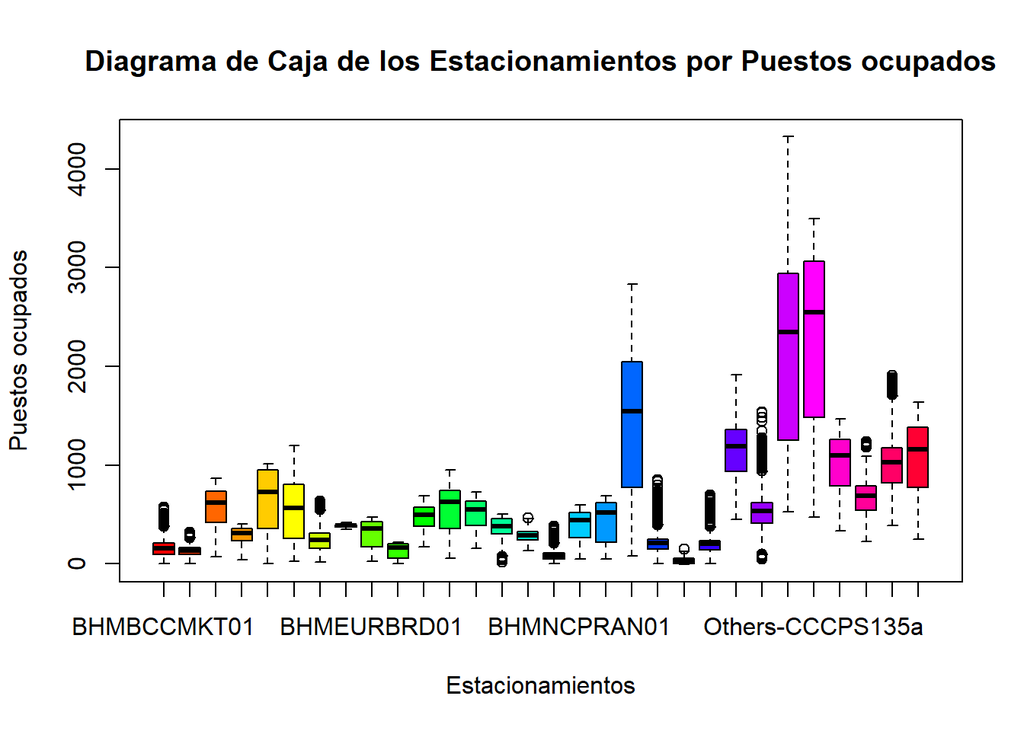

```r
library(dplyr)

boxplot(occupancy ~ system_code_number, data = df_prueba,
        main = "Diagrama de Caja de los Estacionamientos por Puestos ocupados",
        xlab = "Estacionamientos",
        ylab = "Puestos ocupados",
        col = rainbow(length(unique(df$system_code_number))))  # Usar colores diferentes para cada estacionamiento
```

```r
# Crear un data frame vacío para almacenar los resultados
outliers_list <- data.frame()

# Creamos el dataframe para guardar los datos limpios
df_cleaned <- df_prueba

# Iterar sobre cada system_code_number
for (code in unique(df_prueba$system_code_number)) {

  # Filtrar el data frame para el system_code_number actual
  subset_data <- df_prueba[df_prueba$system_code_number == code, ]

  # Calcular Q1 y Q3
  Q1 <- quantile(subset_data$occupancy, 0.25)
  Q3 <- quantile(subset_data$occupancy, 0.75)

  # Calcular el IQR
  IQR_value <- IQR(subset_data$occupancy)

  # Definir límites para identificar outliers
  lower_bound <- Q1 - 1.5 * IQR_value
  upper_bound <- Q3 + 1.5 * IQR_value

  # Identificar valores atípicos
  outliers <- subset_data[subset_data$occupancy < lower_bound | subset_data$occupancy > upper_bound, ]

  # Agregar los resultados a la lista de outliers
  outliers_list <- rbind(outliers_list, outliers)

  # Filtrar el data frame para eliminar valores atípicos
  df_cleaned <- df_cleaned[!(df_cleaned$system_code_number == code &
                               (df_cleaned$occupancy < lower_bound |
                                  df_cleaned$occupancy > upper_bound)), ]
}
```

Comparamos los dataframes con y sin valores atipicos:

```r
summary(df)
```

```
##  system_code_number    capacity      occupancy          mes
##  Length:35717       Min.   : 220   Min.   :  -8.0   Length:35717
##  Class :character   1st Qu.: 500   1st Qu.: 210.0   Class :character
##  Mode  :character   Median : 849   Median : 446.0   Mode  :character
##                     Mean   :1398   Mean   : 642.2
##                     3rd Qu.:2009   3rd Qu.: 798.0
##                     Max.   :4675   Max.   :4327.0
##
##         dia            hora
##  domingo  :4764   Min.   :7H 30M 33S
##  lunes    :5400   1st Qu.:10H 0M 5S
##  martes   :5461   Median :12H 4M 36S
##  miércoles:5461   Mean   :12H 13M 49.263851947253S
##  jueves   :4983   3rd Qu.:14H 29M 49S
##  viernes  :4968   Max.   :16H 34M 28S
##  sábado   :4680
```

```r
summary(df_cleaned)
```

```
##  system_code_number    capacity      occupancy        mes
##  Length:35169       Min.   : 220   Min.   :  -8   Length:35169
##  Class :character   1st Qu.: 500   1st Qu.: 208   Class :character
##  Mode  :character   Median : 863   Median : 445   Mode  :character
##                     Mean   :1398   Mean   : 642
##                     3rd Qu.:2009   3rd Qu.: 797
##                     Max.   :4675   Max.   :4327
##
##         dia            hora
##  domingo  :4630   Min.   :7H 30M 33S
##  lunes    :5355   1st Qu.:9H 59M 52S
##  martes   :5461   Median :12H 4M 2S
##  miércoles:5433   Mean   :12H 12M 12.55526173619S
##  jueves   :4934   3rd Qu.:14H 29M 8S
##  viernes  :4922   Max.   :16H 34M 28S
##  sábado   :4434
```

Diagramas de caja de estacionamientos vs puestos ocupados

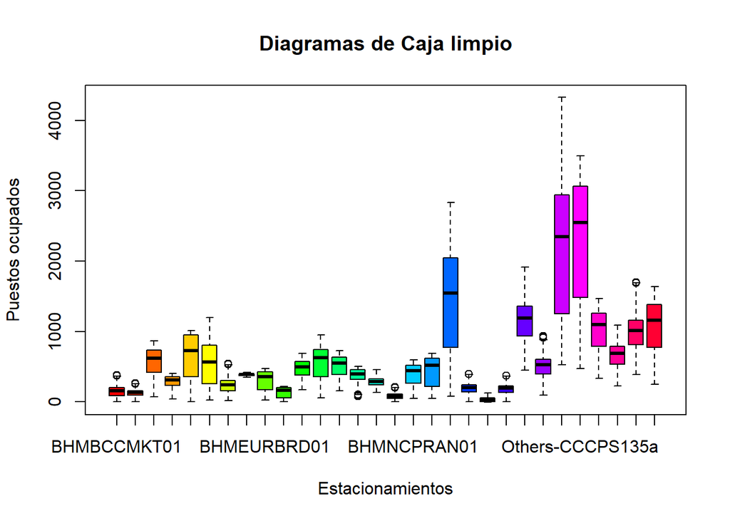

```r
boxplot(occupancy ~ system_code_number, data = df_cleaned,
        main = "Diagramas de Caja limpio",
        xlab = "Estacionamientos",
        ylab = "Puestos ocupados",
        col = rainbow(length(unique(df$system_code_number))))  # Usar colores diferentes para cada estacionamiento
```

Ahora tenemos el conjunto de datos limpio

```r
df = df_cleaned
head(df)
```

```
##   system_code_number capacity occupancy     mes    dia        hora
## 1        BHMBCCMKT01      577        61 octubre martes  7H 59M 42S
## 2        BHMBCCMKT01      577        64 octubre martes  8H 25M 42S
## 3        BHMBCCMKT01      577        80 octubre martes  8H 59M 42S
## 4        BHMBCCMKT01      577       107 octubre martes  9H 32M 46S
## 5        BHMBCCMKT01      577       150 octubre martes  9H 59M 48S
## 6        BHMBCCMKT01      577       177 octubre martes 10H 26M 49S
```

### EXPLORACION DE DATOS

Histogramas por estacionamiento (primeros 15):

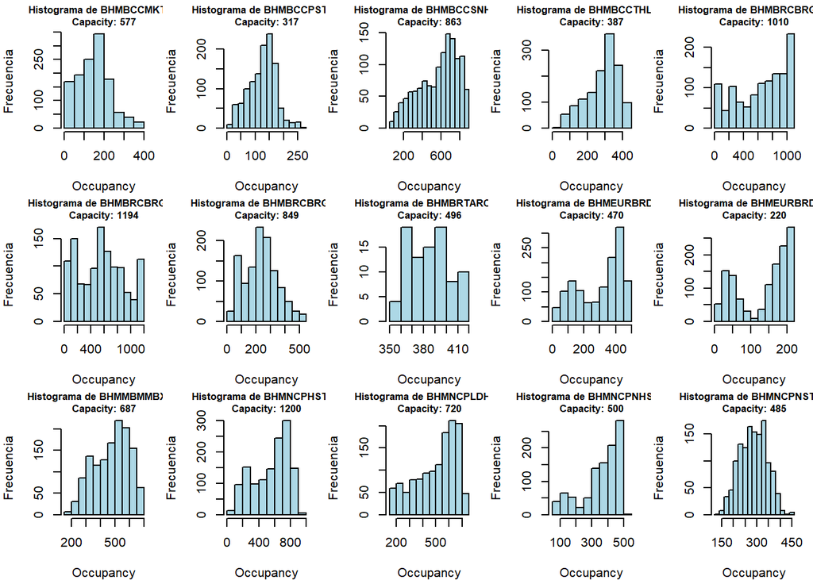

```r
# Configurar la disposición de los gráficos para los primeros histogramas
par(mfrow = c(3, 5), mar = c(4, 4, 2, 1))  # 3 fila y 5 columnas

# Crear histogramas para los primeros
for (code in unique(df$system_code_number)[1:15]) {
  subset_data <- df[df$system_code_number == code, ]

  # Calcular el valor máximo de capacity
  max_capacity <- max(subset_data$capacity)

  hist(subset_data$occupancy,
       main = paste("Histograma de", code, "\nCapacity:", max_capacity),  # Título del histograma,  # Título del histograma
       xlab = "Occupancy",                    # Etiqueta del eje X
       ylab = "Frecuencia",                   # Etiqueta del eje Y
       col = "lightblue",                     # Color de las barras
       border = "black",
       cex.main = 0.8)                      # Color del borde de las barras
}
```

Histogramas por estacionamiento (ultimos 15):

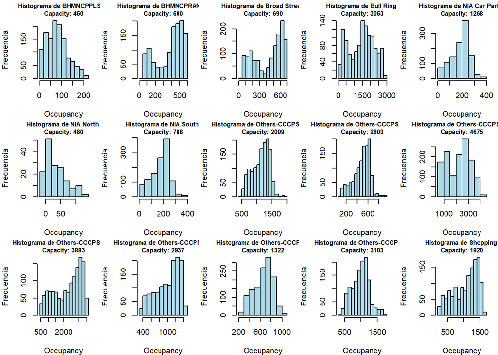

```r
# Configurar la disposición de los gráficos para los histogramas
par(mfrow = c(3, 5), mar = c(4, 4, 2, 1))  # 3 filas y 5 columnas


# Crear histogramas
for (code in unique(df$system_code_number)[16:30]) {
  subset_data <- df[df$system_code_number == code, ]

  # Calcular el valor máximo de capacity
  max_capacity <- max(subset_data$capacity)

  hist(subset_data$occupancy,
       main = paste("Histograma de", code, "\nCapacity:", max_capacity),  # Título del histograma,  # Título del histograma
       xlab = "Occupancy",                    # Etiqueta del eje X
       ylab = "Frecuencia",                   # Etiqueta del eje Y
       col = "lightblue",                     # Color de las barras
       border = "black",
       cex.main = 0.8)                      # Color del borde de las barras
}
```

Diagramas de barras

Diagrama de barras del estacionamiento y las horas en que tiene puestos ocupados, horas (eje x) vs ocupados (eje y)

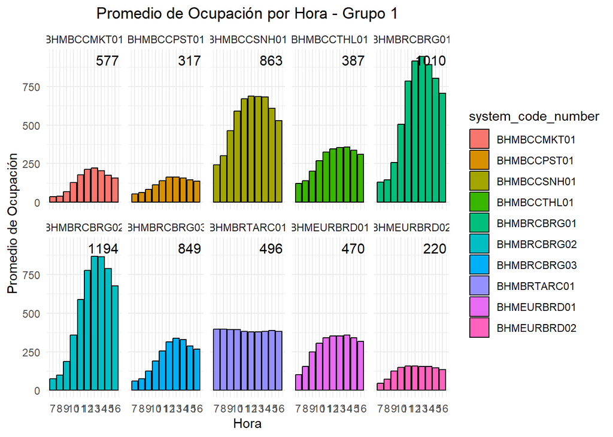

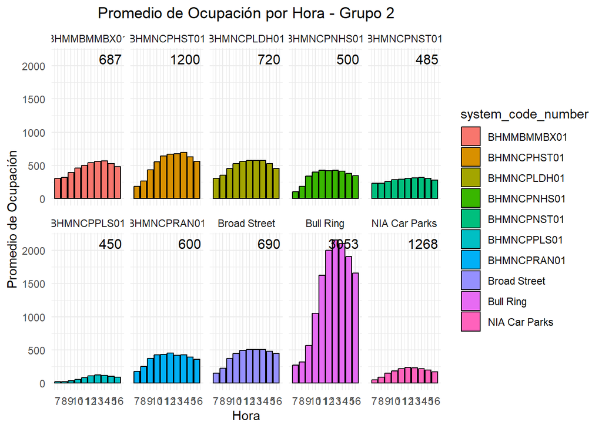

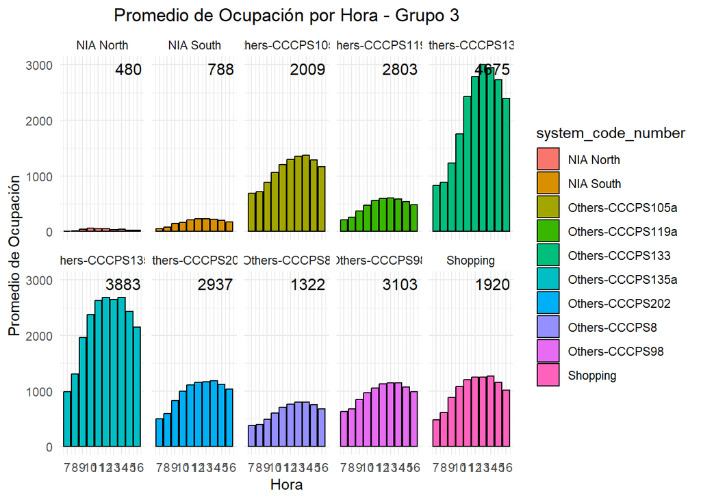

```r
# install.packages("ggplot2")
library(ggplot2)
library(dplyr)
library(tidyr)

# Convertir hora a formato numérico
df$hora_num <- as.numeric(sub("H.*", "", df$hora))

# Calcular el promedio de ocupación y el máximo de capacidad por system_code_number y hora
df_summary <- df %>%
  group_by(system_code_number, hora_num) %>%
  summarise(promedio_occupancy = mean(occupancy, na.rm = TRUE),
            max_capacity = max(capacity, na.rm = TRUE), .groups = 'drop') %>%
  ungroup()

# Dividir los system_code_number en grupos de 10
unique_codes <- unique(df_summary$system_code_number)
num_groups <- ceiling(length(unique_codes) / 10)

# Crear gráficos de 10 en 10
for (i in 0:(num_groups - 1)) {
  # Obtener el grupo actual de system_code_number
  current_codes <- unique_codes[(i * 10 + 1):min((i + 1) * 10, length(unique_codes))]

  # Filtrar el resumen para el grupo actual
  df_group <- df_summary %>% filter(system_code_number %in% current_codes)


  # Crear el gráfico de barras para el grupo actual
  p <- ggplot(df_group, aes(x = hora_num, y = promedio_occupancy, fill = system_code_number)) +
    geom_bar(stat = "identity", position = "dodge", color = "black") +
    scale_x_continuous(breaks = 7:16) +
    labs(title = paste("Promedio de Ocupación por Hora - Grupo", i + 1),
         x = "Hora",
         y = "Promedio de Ocupación") +
    theme_minimal() +
    facet_wrap(~ system_code_number, nrow = 2, ncol = 5) +  # Ajustar filas y columnas
    geom_text(aes(label = ""),
              position = position_dodge(width = 0.9),
              vjust = -0.5, size = 3) +  # Añadir el valor máximo de capacidad como texto
    theme(plot.title = element_text(hjust = 0.5))  # Centrar el título

  # Añadir el valor de capacidad debajo del título
  capacity_label <- df_group %>%
    group_by(system_code_number) %>%
    summarise(capacity = unique(max_capacity))

  p <- p + geom_text(data = capacity_label,
                     aes(label = capacity),
                     x = Inf, y = Inf,
                     vjust = 1.5, hjust = 1.1, size = 4)  # Ajustar la posición según sea necesario

  # Mostrar el gráfico
  print(p)
}
```

CORRELACIONES

Se debe verificar si hay correlaciones entre las variables que no se van a predecir. De ser así, debe salir una de ellas del modelo

```r
df_copia <- data.frame(df)
```

Calcular la matriz de correlación

Convertir variables categóricas a numéricas

```r
sapply(df, class)
```

```
## $system_code_number
## [1] "character"
##
## $capacity
## [1] "integer"
##
## $occupancy
## [1] "integer"
##
## $mes
## [1] "character"
##
## $dia
## [1] "ordered" "factor"
##
## $hora
## [1] "Period"
## attr(,"package")
## [1] "lubridate"
##
## $hora_num
## [1] "numeric"
```

```r
df_copia$system_code_number <- as.numeric(factor(df_copia$system_code_number))
df_copia$mes <- as.numeric(factor(df_copia$mes))
df_copia$dia <- as.numeric(factor(df_copia$dia))

# Ahora se puede calcular la matriz de correlación
correlacion_matriz <- cor(df_copia[, c("system_code_number", "capacity", "occupancy", "mes", "dia","hora")])
print(correlacion_matriz)
```

```
##                    system_code_number     capacity   occupancy          mes
## system_code_number       1.0000000000  0.674626119  0.48120035  0.015974838
## capacity                 0.6746261192  1.000000000  0.77559957 -0.005840613
## occupancy                0.4812003521  0.775599571  1.00000000 -0.063329467
## mes                      0.0159748378 -0.005840613 -0.06332947  1.000000000
## dia                      0.0045944518  0.007828897  0.03744717 -0.043146502
## hora                     0.0004239343 -0.002476906 -0.01064622  0.004829673
##                             dia          hora
## system_code_number  0.004594452  0.0004239343
## capacity            0.007828897 -0.0024769057
## occupancy           0.037447166 -0.0106462174
## mes                -0.043146502  0.0048296732
## dia                 1.000000000 -0.1388810148
## hora               -0.138881015  1.0000000000
```

Visualizar la matriz de correlación

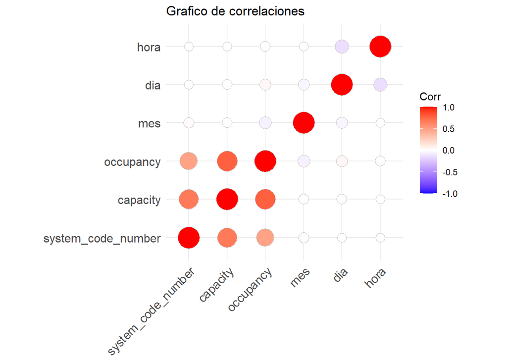

```r
library(ggcorrplot)
plot(ggcorrplot(correlacion_matriz, method = "circle", title = "Grafico de correlaciones"))
```

```r
# En el grafico se visualizará cuan relacionadas están.
```

Estacionamientos con mayores probabilidades de estar desocupado por cada hora

```r
# Extraer la hora de la columna hora
df$hour <- as.numeric(gsub("H.*$", "", df$hora))

# Calcular el porcentaje de puestos desocupados
df$porcentaje_desocupado <- round(((df$capacity - df$occupancy) / df$capacity * 100), 2)

# Calcular promedio por código y hora
resultado <- df %>%
  group_by(system_code_number, hour) %>%
  summarise(
    porcentaje_desocupado = mean(porcentaje_desocupado)
  ) %>%
  ungroup()
# Mostrar resultados
print("Promedio de porcentaje de puestos desocupados por código y hora:")
```

```
## [1] "Promedio de porcentaje de puestos desocupados por código y hora:"
```

```r
print(resultado)
```

```
## # A tibble: 300 × 3
##    system_code_number  hour porcentaje_desocupado
##    <chr>              <dbl>                 <dbl>
##  1 BHMBCCMKT01            7                  93.7
##  2 BHMBCCMKT01            8                  93.1
##  3 BHMBCCMKT01            9                  88.1
##  4 BHMBCCMKT01           10                  77.9
##  5 BHMBCCMKT01           11                  69.3
##  6 BHMBCCMKT01           12                  63.2
##  7 BHMBCCMKT01           13                  61.4
##  8 BHMBCCMKT01           14                  64.7
##  9 BHMBCCMKT01           15                  69.8
## 10 BHMBCCMKT01           16                  73.0
## # ℹ 290 more rows
```

Creamos el grafico para los primeros 10 estacionamientos:

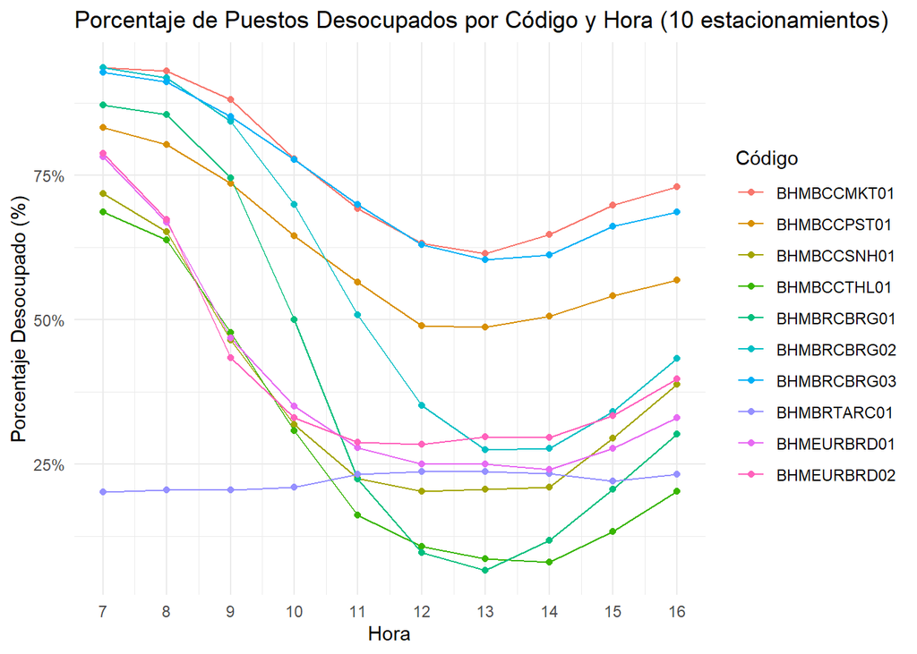

```r
codigos_a_mostrar <- unique(resultado$system_code_number)[1:10]

# Filtrar el dataframe para esos códigos
resultado_filtrado <- resultado %>%
  filter(system_code_number %in% codigos_a_mostrar)

# Crear gráfico con los 10 códigos seleccionados
ggplot(resultado_filtrado, aes(x = hour, y = porcentaje_desocupado, color = system_code_number)) +
  geom_line() +
  geom_point() +
  labs(
    title = "Porcentaje de Puestos Desocupados por Código y Hora (10 estacionamientos)",
    x = "Hora",
    y = "Porcentaje Desocupado (%)",
    color = "Código"
  ) +
  theme_minimal() +
  scale_x_continuous(breaks = 7:16) +
  scale_y_continuous(labels = function(x) paste0(x, "%"))
```

Luego los otros 10:

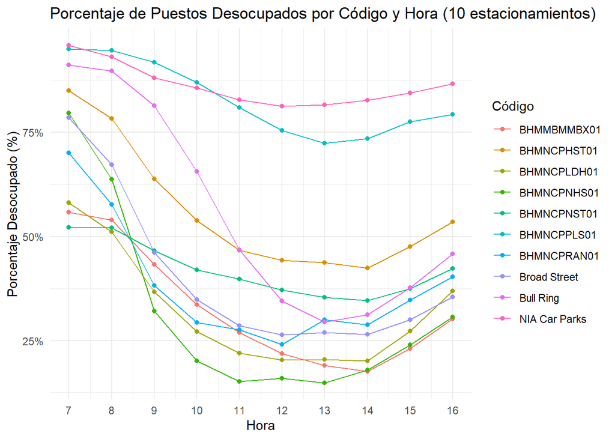

```r
codigos_a_mostrar <- unique(resultado$system_code_number)[11:20]

# Filtrar el dataframe para esos códigos
resultado_filtrado <- resultado %>%
  filter(system_code_number %in% codigos_a_mostrar)

# Crear gráfico con los 10 códigos seleccionados
ggplot(resultado_filtrado, aes(x = hour, y = porcentaje_desocupado, color = system_code_number)) +
  geom_line() +
  geom_point() +
  labs(
    title = "Porcentaje de Puestos Desocupados por Código y Hora (10 estacionamientos)",
    x = "Hora",
    y = "Porcentaje Desocupado (%)",
    color = "Código"
  ) +
  theme_minimal() +
  scale_x_continuous(breaks = 7:16) +
  scale_y_continuous(labels = function(x) paste0(x, "%"))
```

Por ultimo, los ultimos 10:

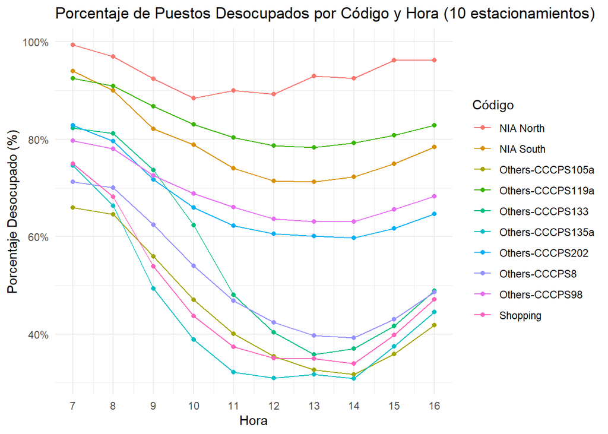

```r
codigos_a_mostrar <- unique(resultado$system_code_number)[21:30]

# Filtrar el dataframe para esos códigos
resultado_filtrado <- resultado %>%
  filter(system_code_number %in% codigos_a_mostrar)

# Crear gráfico con los 10 códigos seleccionados
ggplot(resultado_filtrado, aes(x = hour, y = porcentaje_desocupado, color = system_code_number)) +
  geom_line() +
  geom_point() +
  labs(
    title = "Porcentaje de Puestos Desocupados por Código y Hora (10 estacionamientos)",
    x = "Hora",
    y = "Porcentaje Desocupado (%)",
    color = "Código"
  ) +
  theme_minimal() +
  scale_x_continuous(breaks = 7:16) +
  scale_y_continuous(labels = function(x) paste0(x, "%"))
```